# Introduction to the RASCHplot package

Ann-Sophie Buchardt

Karl Bang Christensen

Sidsel Normann Jensen

August 14, 2023

# Introduction

Visualisation of Rasch item fit using a Conditional Item Characteristic Curve (CICC), which is a curve describing the expected item mean as a function of the total score. It is possible to make an empirical CICC based on the observed data as both the empirical expected item score and the total scores can be calculated from the data. This empirical curve can then be compared to the model-based CICC to visualise item fit. When data is stratified on levels of a factor the CICC can be used to identify differential item functioning (DIF).

Here, you will learn how to use the `RASCHplot` package to do visualisation in the field of IRT models. In particular, visualisation of responses to tests or questionnaires (`BARplot`), visualisation of Rasch model fit (`CICCplot`), and visualisation of differential item functioning (`DIFplot`). Furthermore, repeated random sampling to obtain a sampling distribution for an item fit statistic of interest (`simRASCHstats`).

# Installation

The package is available on GitHub. To install the package, start by installing the `devtools` package. The best way to do this is from CRAN, by typing:

```
install.packages("devtools")
```

Install the `RASCHplot` package from GitHub using the following code.

```
devtools::install_github("ERRTG/RASCHplot", build_vignettes = TRUE)
```

# Quick Start

The aim of this section is to give users a general sense of the package, including the functions, what they do and basic usage. We briefly introduce the functions, see the basic operations and have a look at the outputs. Hopefully, this will give users an idea about the functions available and their purpose, and where to find more information. More details are given in later sections.

First, we load the `RASCHplot` package

```r
library(RASCHplot)
```

The functions in the package are applicable on polytomous as well as dichotomous items. We load the polytomous SPADI data set from the package. Users can either load their own data or use those saved in the workspace.

```r
data(SPADI)
```

The command loads data from this saved R data archive. Data are from a Danish validation study containing responses to the shoulder pain and disability index (SPADI) from 228 patients with rotator-cuff related disorders.

```r
str(SPADI)
```

```
'data.frame':   228 obs. of  16 variables:
 $ gender: int  1 1 1 1 1 1 1 2 2 2 ...
 $ over60: int  1 0 0 0 0 0 0 1 1 1 ...
 $ id    : int  1 2 3 4 5 6 7 8 9 10 ...
 $ P1    : int  3 3 5 3 4 5 3 5 4 4 ...
 $ P2    : int  3 1 2 3 5 4 3 4 4 4 ...
 $ P3    : int  4 3 3 3 5 4 3 5 4 4 ...
 $ P4    : int  3 3 1 2 3 2 3 4 4 4 ...
 $ P5    : int  4 1 2 0 0 4 2 3 1 3 ...
 $ D1    : int  2 2 0 0 3 3 0 4 4 3 ...
 $ D2    : int  1 3 1 4 3 5 1 5 5 4 ...
 $ D3    : int  2 3 1 0 2 3 0 4 4 2 ...
 $ D4    : int  1 3 0 0 2 1 0 1 0 2 ...
 $ D5    : int  1 3 0 0 0 0 0 2 0 3 ...
 $ D6    : int  4 3 1 0 5 4 2 5 5 4 ...
 $ D7    : int  2 4 4 0 4 0 0 1 5 4 ...
 $ D8    : int  1 3 3 0 0 0 0 3 5 4 ...
```

Let us focus on the eight disability items.

```r
itemsIncomp <- SPADI[, 9:16]
```

We can visualise the distribution of responses using the most basic call to `BARplot()`.

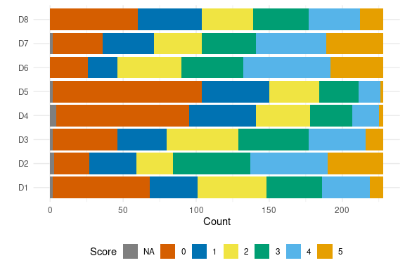

```r
BARplot(itemsIncomp)
```

Visualising Rasch model fit is main motivation for the package.

```r
items <- SPADI[, 9:16]
```

We fit a partial credit model using the `PCM` function from the `eRm` package.

```r
fit <- eRm::PCM(items)
```

We use the most basic call to `CICCplot()` to visualise the model fit of the first item.

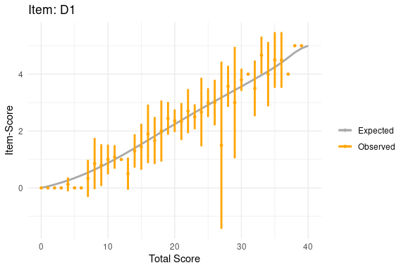

```r
CICCplot(fit)
```

One of the key benefits of the `CICCplot()` function is the ability to impose a grouping on the total score. This is helpful in choosing the plot that best communicates the level of fit or misfit.

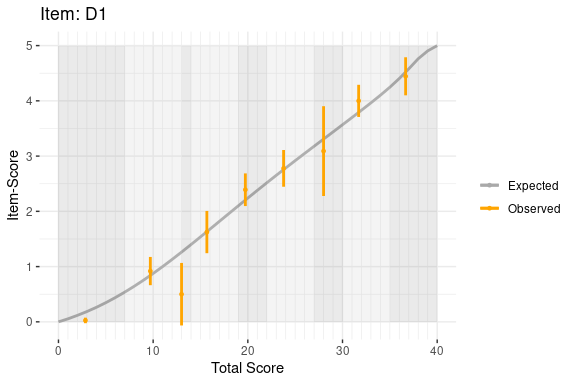

```r
CICCplot(fit, lower.groups = c(0, 7, 13, 14, 19, 22, 27, 30, 35))
```

For more details on the `CICCplot` function see the help vignette `vignette("CICCplot", package = "RASCHplot")`.

To visualise potential differential item functioning (DIF) we can use the `DIFplot` function.

```
$D1
$D1$gender
```

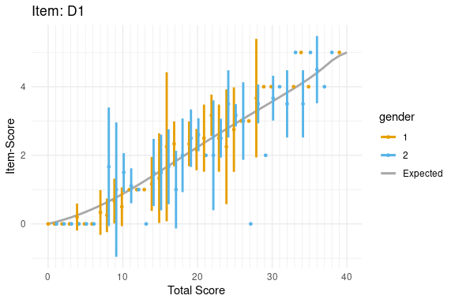

```r
strat.vars <- list(gender = SPADI[, "gender"])
DIFplot(model = fit, strat.vars = strat.vars)
```

For more details on the `DIFplot` function see the help vignette `vignette("DIFplot", package = "RASCHplot")`.

# Empirical critical values for Rasch item fit statistics

## Function: simRASCHstats